# A3: A Fly Guy Analysis

Elisha Jeon

February 20th, 2023

### Introduction

The book I chose to analyze is the Fly Guy series by Tedd Arnold. I remember always reaching for it whenever the class visited the school’s library; it is a childhood favorite for many. This was around 10 years ago, so I have little sense on which books today’s generation of children tend to read today. Has there been an upsurge of new children’s book that has overthrown classics like Fly Guy, or has Fly Guy triumphed even through the changing times? Specifically, I hope to look at the rate of checkouts for Fly Guy throughout the years to find when its popularity peaked — and fell — to discover what social contexts caused such shifts.

### Summary Information

In this data analysis, I retrieved values that could answer these questions:

- **Which** Fly Guy book is the most popular and which is the least?
- **What** is the average number of checkouts for each Fly Guy book
- **How** has the number of checkouts for Fly Guy changed since its publication to now?
- **What** is the highest and lowest checkout number and in which years?
- **Is** the total most checked out Fly Guy book consecutively the most checkout throughout the years?

As for the Fly Guy series’ success in the recent years as a whole, it’s no denying the fall in popularity they have had since 2017. Their most popular year was in 2018 with 12,680 total checkouts; it’s observable that their checkouts fall in the 2017-2019 timeline. Additionally, by subtracting the number of 2017 with 2022 checkouts, I found that there was a difference of 5062, meaning there have been 5062 less checkouts since 2017. Nonetheless, Fly Guy is a treasured childhood memory for me and many others. I hope to see its checkout numbers rise in the future.

### The Dataset

Through their Open Data Program, the Seattle Public Library published their checkouts on physical and electronic items at the library in April 2005. This data is openly available with the goal of increasing transparency and accessibility to the information they collect, and to promote economic development and research. There are twelve observational columns (Usage class, Checkout type, Material Type, Checkout Year, Checkout Month, Checkout count, Title, ISBN, Creator, Subjects, Publisher, and Publication Year) and 42 million rows of checkout counts. This data is contributed by the city of Seattle and their book cravings, and was probably collected to keep track of which books were checked out and available, along with to see which books are popular within the area at the time.

Ethical questions for the library to collect and publish this data are if the patrons are aware they are being used for research and whether they have the option to opt-out of this data collection. While looking over the dataset, I found that a possible problem could arise when a library adds a book to its collection much later than its publication date. Hence, a complete accurate checkout history of the book could not be possible through the library. A limitation is that people might checkout a book and not get to reading it before it has to be returned. So we cannot connect somebody checking out a book to one more person reading the book.

### First Trends Over Time Chart

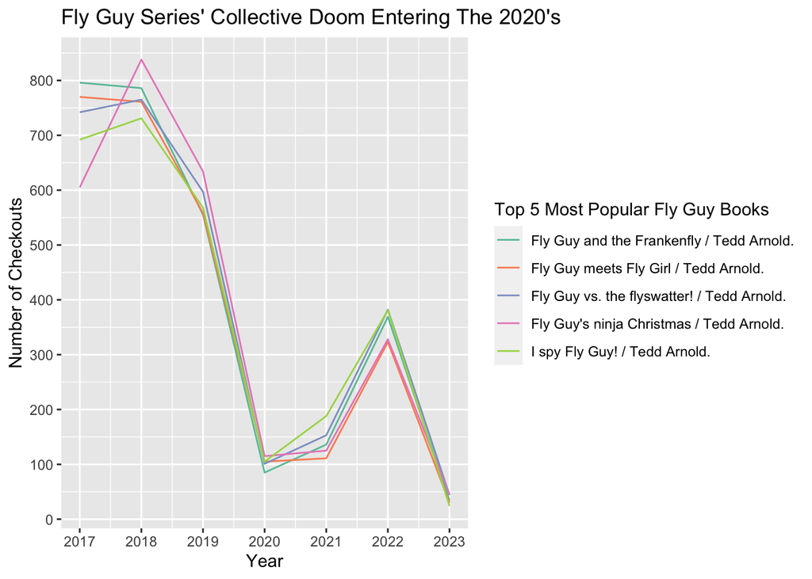

In this line graph, we can see the checkout trends for the top five most popular Fly Guy books in the series over recent years. I was extremely surprised to see that all five Fly Guy books follow an almost identical trend, which means they get a similar amount of total checkouts each year. They started high in 2018 at around a 750 checkouts range, then fell dramatically together in checkouts during 2018 to 2020. This could certainly be a COVID effect. This collectiveness also suggests that whatever the top total checked out Fly Guy book is, it isn’t *exactly* the most popular book — at least not by a landslide. To date, the book that takes the cake for most checked out is “Fly Guy vs. the flyswatter!” with 2784 total checkouts. However, the competition is neck and neck between all five. I am curious to find out why this happens. My best hypothesis is that when children seek to borrow a Fly Guy book, they like to do it in bulk and grab several of them at once. I also did this when I was younger so I could read all of them from only one trip to the library.

### Second Trends Over Time Chart

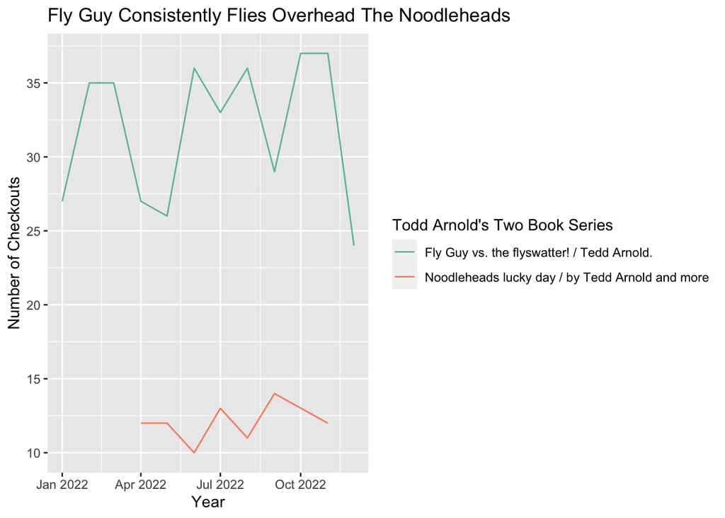

### Bar Chart

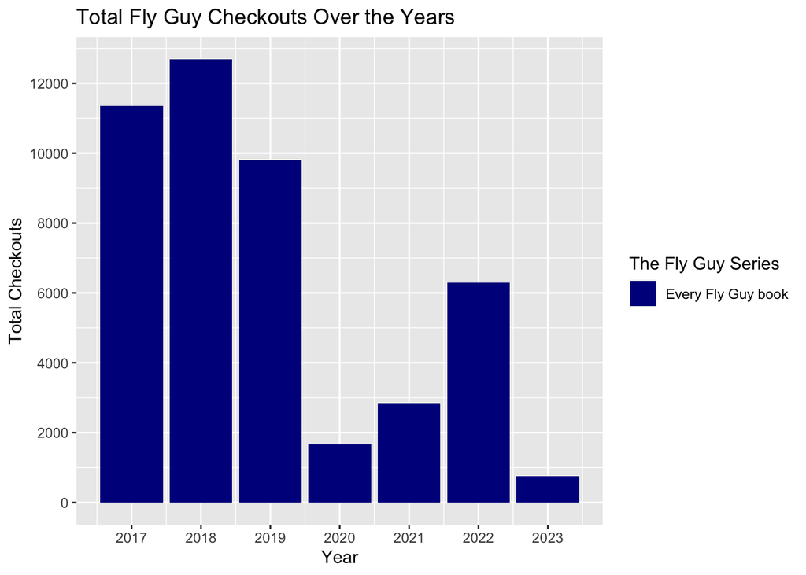